# Practical Machine Learning Project

Deepak

August 7, 2017

## Project Instructions:

One thing that people regularly do is quantify how much of a particular activity they do, but they rarely quantify how well they do it. In this project, your goal will be to use data from accelerometers on the belt, forearm, arm, and dumbell of 6 participants.

### Background

Using devices such as Jawbone Up, Nike FuelBand, and Fitbit it is now possible to collect a large amount of data about personal activity relatively inexpensively. These type of devices are part of the quantified self movement - a group of enthusiasts who take measurements about themselves regularly to improve their health, to find patterns in their behavior, or because they are tech geeks. One thing that people regularly do is quantify how much of a particular activity they do, but they rarely quantify how well they do it. In this project, your goal will be to use data from accelerometers on the belt, forearm, arm, and dumbell of 6 participants. They were asked to perform barbell lifts correctly and incorrectly in 5 different ways. More information is available from the website here: http://web.archive.org/web/20161224072740/http:/groupware.les.inf.puc-rio.br/har (see the section on the Weight Lifting Exercise Dataset).

### Data

The training data for this project are available here: https://d396qusza40orc.cloudfront.net/predmachlearn/pml-training.csv

The test data are available here: https://d396qusza40orc.cloudfront.net/predmachlearn/pml-testing.csv

## Data Preprocessing

```r
set.seed(34343)
## Read the dataset

training<-read.csv("pml-training.csv",header = TRUE)
testing <- read.csv("pml-testing.csv",header = TRUE)
```

Partitioning the Training Data Set into two sets

```r
library(caret)
index <- createDataPartition(y=training$classe,p=.7, list=FALSE)

train<- training[index,]
test<- training[-index,]

dim(train);dim(test)
```

```
## [1] 13737   160
```

```
## [1] 5885  160
```

## Cleaning The Data

Remove Near-Zero Variance Predictors

```r
nzv<- nearZeroVar(train,saveMetrics = TRUE)
train<- train[,nzv$nzv==FALSE]

nzv<- nearZeroVar(test,saveMetrics = TRUE)
test<- test[,nzv$nzv==FALSE]
```

Remove first column of train dataset.

```r
train<- train[,-c(1)]
```

Clear Variables with more than 70 percent of NAs.

```r
temp<- train
i<-0
j<-0
for(i in 1:length(train)){
  if(sum(is.na(train[,i]))/nrow(train) >.7){
    for( j in 1:length(temp)){
     if (length( grep(names(train[i]), names(temp)[j] ))==1){
        temp<- temp[,-j]
     }
    }
  }
}
dim(temp)
```

```
## [1] 13737    58
```

```r
train<- temp
rm(temp)
```

Transform the test and testing datasets

```r
cnames1<- colnames(train)
cnames2<- colnames(train[,-58])

test<- test[cnames1]
testing<- testing[cnames2]
```

Coerce the data into same types.

```r
i<-0
j<-0
for(i in 1:length(testing)){
  for(j in 1:length(train)){
    if( length( grep(names(train[i]), names(testing)[j]) ) == 1){
      class(testing[j]) = class(train[i])
    }
  }
}

testing <- rbind(train[2, -58] , testing)
testing <- testing[-1,]
```

## Prediction with Decision Tree

```r
library(rpart)
library(rpart.plot)
set.seed(34343)

modeldtree<-rpart(classe ~.,data=train,method="class")
predtree<-predict(modeldtree,test,type="class")
cmdtree<- confusionMatrix(test$classe,predtree)
cmdtree
```

```
## Confusion Matrix and Statistics
##
##           Reference
## Prediction    A    B    C    D    E
##          A 1620   42   12    0    0
##          B   55  937  139    8    0
##          C   13   57  940   12    4
##          D    2   44  105  658  155
##          E    0    0   41   73  968
##
## Overall Statistics
##
##                Accuracy : 0.8705
##                  95% CI : (0.8617, 0.879)
##     No Information Rate : 0.2872
##     P-Value [Acc > NIR] : < 2.2e-16
##
##                   Kappa : 0.8361
##  Mcnemar's Test P-Value : NA
##
## Statistics by Class:
##
##                      Class: A Class: B Class: C Class: D Class: E
## Sensitivity            0.9586   0.8676   0.7599   0.8762   0.8589
## Specificity            0.9871   0.9580   0.9815   0.9404   0.9760
## Pos Pred Value         0.9677   0.8227   0.9162   0.6826   0.8946
## Neg Pred Value         0.9834   0.9699   0.9389   0.9811   0.9669
## Prevalence             0.2872   0.1835   0.2102   0.1276   0.1915
## Detection Rate         0.2753   0.1592   0.1597   0.1118   0.1645
## Detection Prevalence   0.2845   0.1935   0.1743   0.1638   0.1839
## Balanced Accuracy      0.9729   0.9128   0.8707   0.9083   0.9175
```

## Prediction with Random Forest

```r
set.seed(34343)
library(randomForest)
modelrf<- randomForest(classe ~., data=train)
predrf<-predict(modelrf,test,type="class")
cmrf<- confusionMatrix(predrf,test$classe)
cmrf
```

```
## Confusion Matrix and Statistics
##
##           Reference
## Prediction    A    B    C    D    E
##          A 1674    3    0    0    0
##          B    0 1136    0    0    0
##          C    0    0 1026    4    0
##          D    0    0    0  957    5
##          E    0    0    0    3 1077
##
## Overall Statistics
##
##                Accuracy : 0.9975
##                  95% CI : (0.9958, 0.9986)
##     No Information Rate : 0.2845
##     P-Value [Acc > NIR] : < 2.2e-16
##
##                   Kappa : 0.9968
##  Mcnemar's Test P-Value : NA
##
## Statistics by Class:
##
##                      Class: A Class: B Class: C Class: D Class: E
## Sensitivity            1.0000   0.9974   1.0000   0.9927   0.9954
## Specificity            0.9993   1.0000   0.9992   0.9990   0.9994
## Pos Pred Value         0.9982   1.0000   0.9961   0.9948   0.9972
## Neg Pred Value         1.0000   0.9994   1.0000   0.9986   0.9990
## Prevalence             0.2845   0.1935   0.1743   0.1638   0.1839
## Detection Rate         0.2845   0.1930   0.1743   0.1626   0.1830
## Detection Prevalence   0.2850   0.1930   0.1750   0.1635   0.1835
## Balanced Accuracy      0.9996   0.9987   0.9996   0.9959   0.9974
```

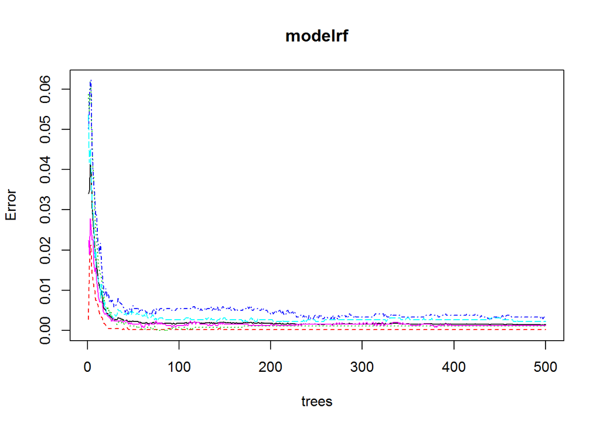

```r
plot(modelrf)
```

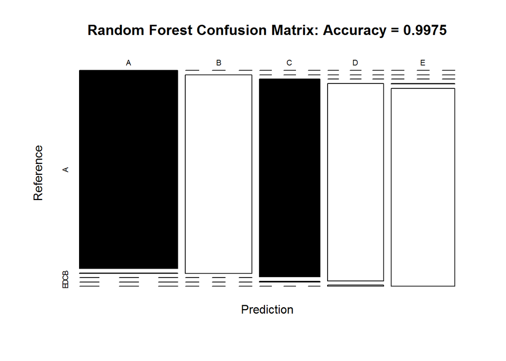

```r
plot(cmrf$table, col = cmrf$byClass, main = paste("Random Forest Confusion Matrix: Accuracy =", round(cmrf$overall['Accuracy'], 4)))
```

## Predicting Results on FinalTest Data

```r
final_pred<-predict(modelrf,testing,type="class")
final_pred
```

```
##  1 21  3  4  5  6  7  8  9 10 11 12 13 14 15 16 17 18 19 20
##  B  A  B  A  A  E  D  B  A  A  B  C  B  A  E  E  A  B  B  B
## Levels: A B C D E
```